# Reproducible Research: Peer Assessment 1

## Loading and preprocessing the data

#### 1. Load the data (i.e. read.csv())

```r
options(scipen = 9, digits = 3 ) # set the options for outputting numbers
measured_activity <- read.csv("activity.csv",header=T, na.string="NA")
```

#### 2. Process/transform the data (if necessary) into a format suitable for your analysis

Sum the steps by date excluding missing records.

```r
total_steps_per_day <- aggregate(measured_activity$steps, by=list(measured_activity$date), FUN=sum, na.rm=TRUE)
colnames(total_steps_per_day) <- c("Day", "Total_Steps")
```

## What is mean total number of steps taken per day?

#### 1. Make a histogram of the total number of steps taken each day

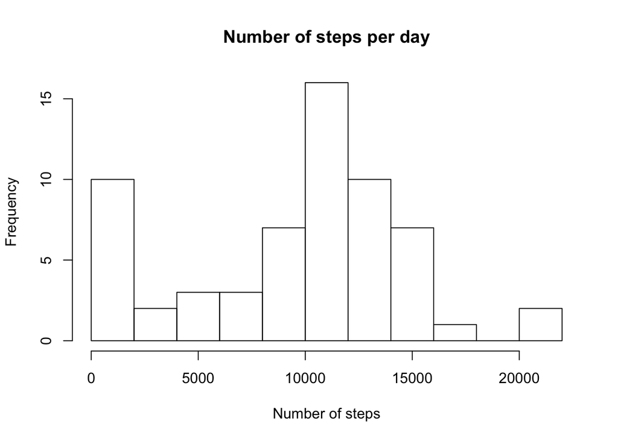

```r
hist(total_steps_per_day$Total_Steps, main="Number of steps per day", xlab="Number of steps", ylab="Frequency", breaks = 10)
```

#### 2. Calculate and report the mean and median total number of steps taken per day

```r
mean_total_steps_per_day <- mean(total_steps_per_day$Total_Steps, na.rm=TRUE)
median_total_steps_per_day <- median(total_steps_per_day$Total_Steps, na.rm=TRUE)
```

Mean of total number of steps per day equals to `9354.23` and median of the same variable equals to `10395`.

## What is the average daily activity pattern?

#### 1. Make a time series plot (i.e. type = “l”) of the 5-minute interval (x-axis) and the average number of steps taken, averaged across all days (y-axis)

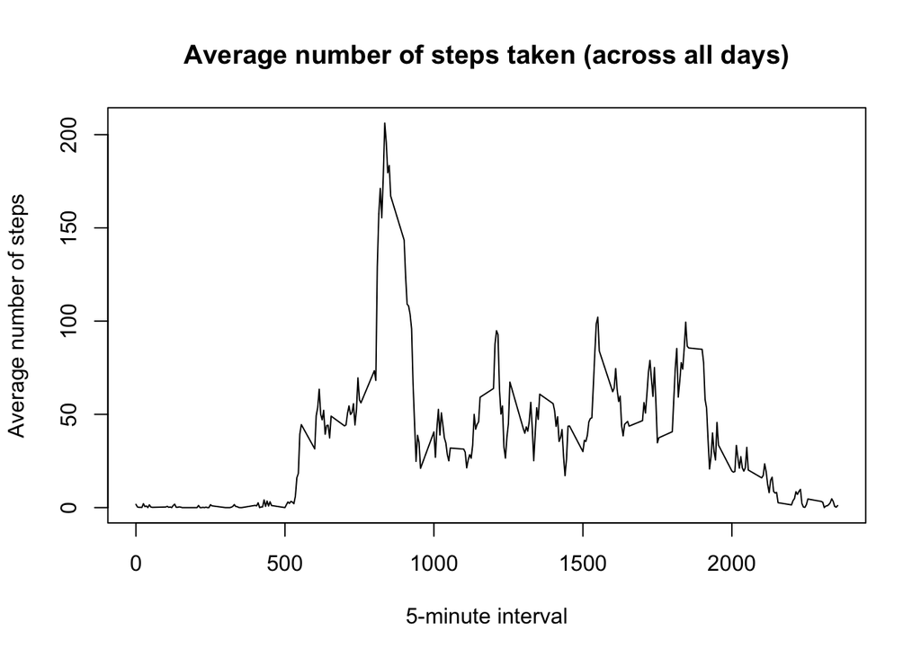

```r
avg_steps_per_interval <- aggregate(measured_activity$steps, by=list(measured_activity$interval), FUN=mean, na.rm=TRUE)
colnames(avg_steps_per_interval) <- c("Interval", "Average_Steps")
with(avg_steps_per_interval, plot(Interval, Average_Steps, type="l", main = "Average number of steps taken (across all days)", xlab = "5-minute interval", ylab="Average number of steps"))
```

#### 2. Which 5-minute interval, on average across all the days in the dataset, contains the maximum number of steps?

```r
interval_with_max_steps <- avg_steps_per_interval[which.max(avg_steps_per_interval$Average_Steps),1]
```

5 minute interval `835` is the one containing maximum number of steps on average across all the days in dataset.

## Imputing missing values

#### 1. Calculate and report the total number of missing values in the dataset (i.e. the total number of rows with NAs)

```r
missing_records <- nrow(measured_activity) - sum(complete.cases(measured_activity))
```

The dataset has in total `2304` missing records.

#### 2. Devise a strategy for filling in all of the missing values in the dataset. The strategy does not need to be sophisticated. For example, you could use the mean/median for that day, or the mean for that 5-minute interval, etc.

Since the only NA’s are in number of steps, it is most logical to me to use mean of that 5-minute interval across the dataset. The assumption is - activity patterns / activity intensity is in relation to advancement of the day. Average of all interval values for the specific interval is a decent fit of missing value.

#### 3. Create a new dataset that is equal to the original dataset but with the missing data filled in.

```r
library(plyr)
measured_activity_imputed <- ddply(measured_activity,
      .(interval),
      transform,
      steps=ifelse(is.na(steps), as.integer(mean(steps, na.rm=TRUE)), steps))
```

```r
missing_records_imputed <- nrow(measured_activity_imputed) - sum(complete.cases(measured_activity_imputed))
```

To verify that there are no missing records in imputed dataset, we can try substract sum of complete cases from number of rows in dataset. As we see substraction equals to `0` (denoting no missing records).

#### 4. Make a histogram of the total number of steps taken each day and Calculate and report the mean and median total number of steps taken per day. Do these values differ from the estimates from the first part of the assignment? What is the impact of imputing missing data on the estimates of the total daily number of steps?

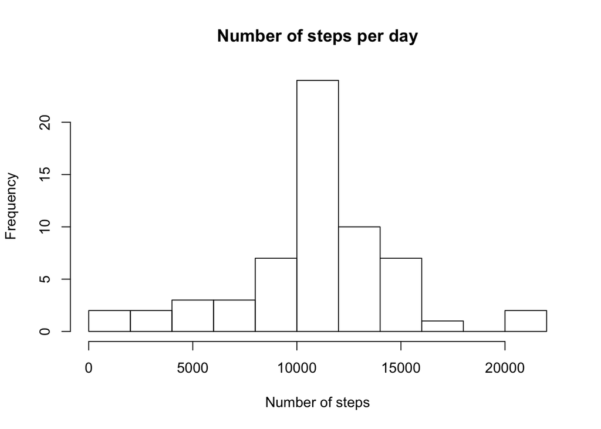

```r
total_steps_per_day_imputed <- aggregate(measured_activity_imputed$steps, by=list(measured_activity_imputed$date), FUN=sum, na.rm=TRUE)
colnames(total_steps_per_day_imputed) <- c("Day", "Total_Steps")
total_steps_per_day_imputed$Total_Steps <- as.numeric(as.character(total_steps_per_day_imputed$Total_Steps))
hist(total_steps_per_day_imputed$Total_Steps, main="Number of steps per day", xlab="Number of steps", ylab="Frequency", breaks = 10)
```

```r
mean_of_set_with_imputed <- mean(total_steps_per_day_imputed$Total_Steps, na.rm=TRUE)
```

```r
median_of_set_with_imputed <- median(total_steps_per_day_imputed$Total_Steps, na.rm=TRUE)
```

As expected, imputed records influenced mainly mean of the dataset which turned from `9354.23` to `10749.77`. The reason is characteristic of mean variable - representing average value. Since we imputed average values, it went up. Median was influenced as well, but not in that extent. Again it went up from `10395` to `10641`.

## Are there differences in activity patterns between weekdays and weekends?

#### 1. Create a new factor variable in the dataset with two levels – “weekday” and “weekend” indicating whether a given date is a weekday or weekend day.

```r
measured_activity_imputed$weekend <- factor(ifelse(weekdays(as.Date(measured_activity_imputed$date))
                                                   %in% c('Saturday','Sunday'), 'Weekend', 'Weekday'))
avg_steps_per_interval_imputed <- aggregate(measured_activity_imputed$steps, by=list(measured_activity_imputed$interval, measured_activity_imputed$weekend), FUN=mean, na.rm=TRUE)
colnames(avg_steps_per_interval_imputed) <- c("Interval", "Weekend", "Average_Steps")
```

#### 2. Make a panel plot containing a time series plot (i.e. type = “l”) of the 5-minute interval (x-axis) and the average number of steps taken, averaged across all weekday days or weekend days (y-axis)

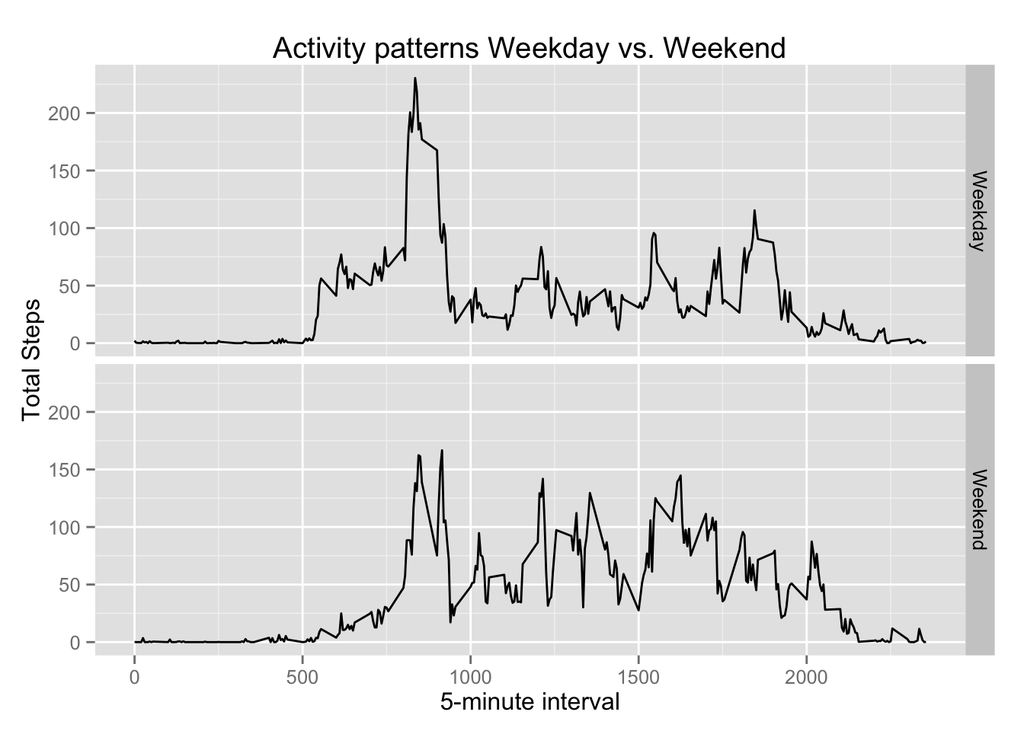

```r
library(ggplot2)
qplot(data = avg_steps_per_interval_imputed, x = Interval, y = Average_Steps, facets = Weekend ~ ., geom = "line", main="Activity patterns Weekday vs. Weekend", ylab = "Total Steps", xlab="5-minute interval")
```